# Umer Saeed

### b) AND Logical Operator

- If Both inputs are FALSE then output is FALSE.
- If Both input is TRUE then output is TRUE.
- If any input is FALSE then output is FALSE.

```python
Image(filename='AND.png')
```

[output not shown]

- Symbol:and
- Description: If both the operands are true then the condition is true.

```python
condition1=100>10
condition2=1>2
condition1 and condition2
```

```
False
```

### c) OR Logical Operator

- If Both inputs are FALSE then output is FALSE.
- If Bout input is TRUE then output is TRUE.
- If any input is TRUE then output is TRUE.

```python
Image(filename='OR.png')
```

[output not shown]

- Symbol: or
- Description: If any of the two operands are non-zero, then the condition is true.

```python
condition1=100>10
condition2=1>2
condition1 or condition2
```

```
True
```

### 5- Identity Operators

```python
YouTubeVideo('x7e6IsBe4B4',width=900, height=500)
```

[video not shown]

- For comparing memory locations of two objects, identity operators are used.
- There are two types of Python identity operators;
- 1- is
- 2- is not

### 1- is

- Symbol: is
- Operator Name: is
- Description: The result becomes true if values on either side of the operator point to the same object and False otherwise.

```python
umer=1
type(umer) is str
```

```
False
```

```python
a=42
b='42'
a is b
```

```
False
```

### 2- is not

- Symbol: is not
- Operator Name: is not
- Description: The result becomes False if the variables on either side of the operator points to the same object

```python
ali="Hello"
type(ali) is not str
```

```
False
```

```python
a=42
b='42'
a is not b
```

```
True
```

### 6-Bitwise Operators

```python
YouTubeVideo('PyfKCvHALj8',width=900, height=500)
```

[video not shown]

- These operators are used to manipulate with bits & performs bit-by-bit operations.
- There are six types of bitwise operators supported by Python.
- 1- Binary AND
- 2- Binary OR
- 3- Binary XOR
- 4- Binary 1s Complement
- 5- Binary Left Shift
- 6- Binary Right Shift

### 1- Binary AND

- Symbol: &
- Operator Name:Binary AND
- Description: This operator copies the bit to the result if it exists in both operands.

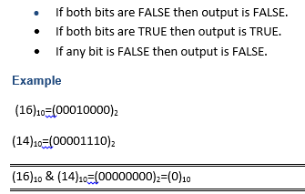

```python
Image(filename='1_BinaryAND.png')
```

```python
a=16
b=14
a&b
```

```
0
```

### 2- Binary OR

- Symbol: |
- Operator Name: Binary OR
- Description:This operator copies the bit if it exists in either of the operands.

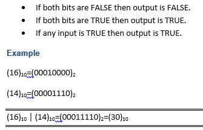

```python
Image(filename='2_BinaryOR.png')
```

```python
a=16
b=14
a|b
```

```
30
```

### 3- Binary XOR

- Symbol: ^
- Operator Name:Binary XOR
- Description:This operator copies the bit if it is set in one operand but not both.

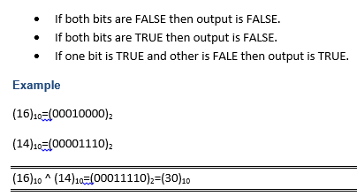

```python
Image(filename='3_BinaryXOR.png')
```

```python
a=16
b=14
a^b
```

```
30
```

### 4- Binary 1s Complement

- Symbol: ~
- perator Name: Binary 1s Complement
- Description:This is a unary operator and has the ability of 'flipping' bits.

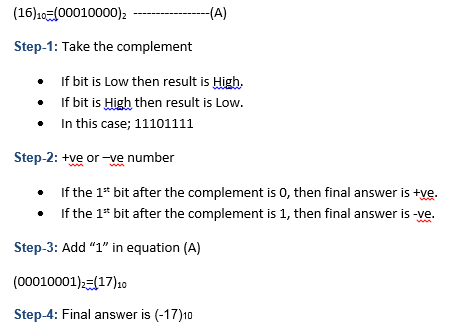

```python
Image(filename='4_Binary1sComplement.png')
```

```python
a=16
~a
```

```
-17
```

### 5- Binary Left Shift

- Symbol: <<
- Operator Name:Binary Left Shift
- Description:The left operands value is moved left by the number of bits specified by the right operand using this operator.

```python
Image(filename='5-BinaryLeftShift.png')
```

[output not shown]

```python
a=16
b=14
b<<2
```

```
56
```

### 6- Binary Right Shift

- Symbol:** >>
- Operator Name:Binary Right Shift
- Description:The left operands value is moved right by the number of bits specified by the right operand using this operator.

```python
Image(filename='6-BinaryRightShift.png')
```

[output not shown]

```python
a=16
b=14
b>>2
```

```
3
```

### 7-Membership Operators

- Python Membership Operators are;
- 1- in
- 2- not in

### 1- in

- Symbol: in
- Operator Name: in
- Description:The result of this operation becomes True if it finds a value in a specified sequence & False otherwise.

```python
srt1="My Name is Umer Saeed"
```

```python
"Umer" in srt1
```

```
True
```

```python
"Ali" in srt1
```

```
False
```

### 2- not in

- Symbol: not in
- Operator Name:not in
- Description:The result of this operation becomes True if it doesn't find a value in a specified sequence & False otherwise.

```python
srt1="My Name is Umer Saeed"
```

```python
"Ali" not in srt1
```

```
True
```

# Chapter 4: Python String

# 4.1 Python String

- A string is simply a series of characters. Anything inside quotes is considered a string in Python, and you can use single or double quotes around your strings like this:
- “This is a string”

```python
YouTubeVideo('iAzShkKzpJo',width=900, height=500)
```

[video not shown]

# 4.2 Rules Applied in String Construction

- 1- The quotes at the beginning and end of a string should be both double quotes or both single quote. They can not be mixed.

### Example-1

```python
name="My Name is Umer Saeed"
```

### Example-2

```python
name='My Name is Umer Saeed'
```

### Example-3

```python
name="My Name is Umer Saeed'
```

```
  File "<ipython-input-194-a40e3400d1bc>", line 1
    name="My Name is Umer Saeed'
                                ^
SyntaxError: EOL while scanning string literal
```

- 2- Double quotes can be inserted into a string starting and ending with single quote.

```python
student='I am Student of "MS Data Science Program"'
```

```python
message = '"!$*#@ you!" she replied'
```

- 3-Single quote can be inserted into a string starting and ending with double quotes.

```python
student="I am Student of 'MS Data Science Program'"
```

```python
message = "'!$*#@ you!' she replied"
```

- 4- Double quotes can not be inserted into a string starting and ending with double quotes.

```python
sudent="I am Student of "MS Data Science Program""
```

```
  File "<ipython-input-199-941a91e25ec3>", line 1
    sudent="I am Student of "MS Data Science Program""
                              ^
SyntaxError: invalid syntax
```

- 5- Double quotes can be inserted into a string starting and ending with double quotes using \ .

```python
stlength = "Once again he asked \"How long is a piece of string?\""
```

- 6- Single quote can not be inserted into a string starting and ending with single quote.

```python
sudent='I am Student of 'MS Data Science Program''
```

```
  File "<ipython-input-201-a9b0afd0a06d>", line 1
    sudent='I am Student of 'MS Data Science Program''
                              ^
SyntaxError: invalid syntax
```

- 7- Multi Line String

```python
mlst=""" Hello,
how are you?,
whats going on?
"""
```

### Escape Sequence

- [More information](https://linuxconfig.org/list-of-python-escape-sequence-characters-with-examples)

```python
YouTubeVideo('4IydORt8qZk',width=900, height=500)
```

[video not shown]

### 1- \newline

- Description: Backslash and newline ignored

```python
esil="""Hello,\
how are you?,
whats going on?"""
print(esil)
```

```
Hello,how are you?,
whats going on?
```

### 2- \a

- Description: ASCII Bell (BEL)

```python
esil="""Hello,\a
how are you?,
whats going on?"""
print(esil)
```

```
Hello,
how are you?,
whats going on?
```

### 3-\b

Description: ASCII Backspace (BS):: ASCII backspace ( BS ) removes previous character

```python
esil="F2017313014@umt.edu.pk"
print(esil)
```

```
F2017313014@umt.edu.pk
```

```python
esil="F2017313014\b@umt.edu.pk"
print(esil)
```

```
F2017313014@umt.edu.pk
```

### 4-r

- ASCII carriage return (CR).
- Moves all characters after ( CR ) the the beginning of the line while overriding same number of characters moved.

```python
print('c:\Data\nan')
```

```
c:\Data
an
```

```python
print(r'c:\Data\nan')
```

```
c:\Data\nan
```

### 5- \n

- Description: ASCII Linefeed (LF)

```python
esil=""" Hello,\n
how are you?,
whts going on?
"""
print(esil)
```

```
 Hello,

how are you?,
whts going on?
```

### 6-\t

- Description: ASCII Horizontal Tab (TAB)

```python
Family="Umer Saeed Ali Saeed Ahmed Abdullah Saeed"
Family
```

```
'Umer Saeed Ali Saeed Ahmed Abdullah Saeed'
```

```python
Family="Umer Saeed\t Ali Saeed\t Ahmed Abdullah Saeed"
print(Family)
```

```
Umer Saeed	 Ali Saeed	 Ahmed Abdullah Saeed
```

# 4.3 Python String Operations

```python
YouTubeVideo('xp2kivGT1_k',width=900, height=500)
```

[video not shown]

```python
YouTubeVideo('PNoP79KxI98',width=900, height=500)
```

[video not shown]

### String slices

- A segment of a string is called a slice.

```python
a = "Hello, World!"
print(a[0])
```

```
H
```

```python
a = "Hello, World!"
print(a[2:5])
```

```
llo
```

```python
a = "Hello, World!"
print(a[3:])
```

```
lo, World!
```

```python
a = "Hello, World!"
print(a[:3])
```

```
Hel
```

```python
a = "Hello, World!"
print(a[0:-2])
```

```
Hello, Worl
```

```python
a = "Hello, World!"
a[0:0]
```

```
''
```

### Replace

- The replace() method replaces a string with another string:

```python
a = "Hello, World!"
print(a.replace("H", "J"))
```

```
Jello, World!
```

### Strip

```python
a = " Hello, World! "
print(a.strip())
```

```
Hello, World!
```

```python
a
```

```
' Hello, World! '
```

### lower()

- The lower() method returns the string in lower case:

```python
a = "HELLO, World!"
print(a.lower())
```

```
hello, world!
```

### islower

```python
a = "hello world!"
print(a.islower())
```

```
True
```

### upper()

- The upper() method returns the string in upper case:

```python
a = "Hello, World!"
print(a.upper())
```

```
HELLO, WORLD!
```

### isupper

```python
a = 'HELLO WORLD!'
print(a.isupper())
```

```
True
```